# GAMA-12 master catalogue

## Preparation of UKIRT Infrared Deep Sky Survey / Large Area Survey (UKIDSS/LAS)

Information about UKIDSS can be found at http://www.ukidss.org/surveys/surveys.html

The catalogue comes from `dmu0_UKIDSS-LAS`.

In the catalogue, we keep:

- The identifier (it's unique in the catalogue);
- The position;
- The stellarity;
- The magnitude for each band in aperture 3 (2 arcsec).
- The hall magnitude is described as the total magnitude.

J band magnitudes are available in two eopchs. We take the first arbitrarily.

The magnitudes are “*Vega like*”. The AB offsets are given by Hewett *et al.* (2016):

| Band | AB offset |
| --- | --- |
| Y | 0.634 |
| J | 0.938 |
| H | 1.379 |
| K | 1.900 |

Each source is associated with an epoch. These range between 2005 and 2007. We take 2006 for the epoch.

```python
from herschelhelp_internal import git_version
print("This notebook was run with herschelhelp_internal version: \n{}".format(git_version()))
```

```
This notebook was run with herschelhelp_internal version:
44f1ae0 (Thu Nov 30 18:27:54 2017 +0000)
```

```python
%matplotlib inline
#%config InlineBackend.figure_format = 'svg'

import matplotlib.pyplot as plt
plt.rc('figure', figsize=(10, 6))

from collections import OrderedDict
import os

from astropy import units as u
from astropy.coordinates import SkyCoord
from astropy.table import Column, Table
import numpy as np

from herschelhelp_internal.flagging import  gaia_flag_column
from herschelhelp_internal.masterlist import nb_astcor_diag_plot, remove_duplicates
from herschelhelp_internal.utils import astrometric_correction, mag_to_flux
```

```python
OUT_DIR =  os.environ.get('TMP_DIR', "./data_tmp")
try:
    os.makedirs(OUT_DIR)
except FileExistsError:
    pass

RA_COL = "las_ra"
DEC_COL = "las_dec"
```

## I - Column selection

```python
#Is the following standard (different names for radec vs mag)?
imported_columns = OrderedDict({
        'SOURCEID': 'las_id',
        'RA': 'las_ra',
        'Dec': 'las_dec',
        'YHALLMAG': 'm_ukidss_y',
        'YHALLMAGERR': 'merr_ukidss_y',
        'YAPERMAG3': 'm_ap_ukidss_y',
        'YAPERMAG3ERR': 'merr_ap_ukidss_y',
        'J_1HALLMAG': 'm_ukidss_j',
        'J_1HALLMAGERR': 'merr_ukidss_j',
        'J_1APERMAG3': 'm_ap_ukidss_j',
        'J_1APERMAG3ERR': 'merr_ap_ukidss_j',
        'HAPERMAG3': 'm_ap_ukidss_h',
        'HAPERMAG3ERR': 'merr_ap_ukidss_h',
        'HHALLMAG': 'm_ukidss_h',
        'HHALLMAGERR': 'merr_ukidss_h',
        'KAPERMAG3': 'm_ap_ukidss_k',
        'KAPERMAG3ERR': 'merr_ap_ukidss_k',
        'KHALLMAG': 'm_ukidss_k',
        'KHALLMAGERR': 'merr_ukidss_k',
        'PSTAR': 'las_stellarity'
    })

catalogue = Table.read(
    "../../dmu0/dmu0_UKIDSS-LAS/data/UKIDSS-LAS_GAMA-12.fits")[list(imported_columns)]
for column in imported_columns:
    catalogue[column].name = imported_columns[column]

#Epochs between 2005 and 2007. Rough average:
epoch = 2006

# Clean table metadata
catalogue.meta = None
```

```
WARNING: UnitsWarning: 'RADIANS' did not parse as fits unit: At col 0, Unit 'RADIANS' not supported by the FITS standard.  [astropy.units.core]
```

```python
# Adding flux and band-flag columns
for col in catalogue.colnames:
    if col.startswith('m_'):

        errcol = "merr{}".format(col[1:])

        # LAS uses a huge negative number for missing values
        catalogue[col][catalogue[col] < -100] = np.nan
        catalogue[errcol][catalogue[errcol] < -100] = np.nan

        # Vega to AB correction
        if col.endswith('y'):
            catalogue[col] += 0.634
        elif col.endswith('j'):
            catalogue[col] += 0.938
        elif col.endswith('h'):
            catalogue[col] += 1.379
        elif col.endswith('k'):
            catalogue[col] += 1.900
        else:
            print("{} column has wrong band...".format(col))

        flux, error = mag_to_flux(np.array(catalogue[col]), np.array(catalogue[errcol]))

        # Fluxes are added in µJy
        catalogue.add_column(Column(flux * 1.e6, name="f{}".format(col[1:])))
        catalogue.add_column(Column(error * 1.e6, name="f{}".format(errcol[1:])))

        # Band-flag column
        if "ap" not in col:
            catalogue.add_column(Column(np.zeros(len(catalogue), dtype=bool), name="flag{}".format(col[1:])))

# TODO: Set to True the flag columns for fluxes that should not be used for SED fitting.
```

```python
catalogue[:10].show_in_notebook()
```

<Table masked=True length=10>

| idx | las_id | las_ra | las_dec | m_ukidss_y | merr_ukidss_y | m_ap_ukidss_y | merr_ap_ukidss_y | m_ukidss_j | merr_ukidss_j | m_ap_ukidss_j | merr_ap_ukidss_j | m_ap_ukidss_h | merr_ap_ukidss_h | m_ukidss_h | merr_ukidss_h | m_ap_ukidss_k | merr_ap_ukidss_k | m_ukidss_k | merr_ukidss_k | las_stellarity | f_ukidss_y | ferr_ukidss_y | flag_ukidss_y | f_ap_ukidss_y | ferr_ap_ukidss_y | f_ukidss_j | ferr_ukidss_j | flag_ukidss_j | f_ap_ukidss_j | … |
| --- | --- | --- | --- | --- | --- | --- | --- | --- | --- | --- | --- | --- | --- | --- | --- | --- | --- | --- | --- | --- | --- | --- | --- | --- | --- | --- | --- | --- | --- | --- |
| 0 | 433868214611 | 177.621028054 | -0.657633289682 | nan | nan | nan | nan | 20.2822 | 0.27995 | 20.0034 | 0.203765 | 19.4475 | 0.0946257 | 19.5657 | 0.143791 | 19.7498 | 0.159388 | 19.3611 | 0.215073 | 0.944606 | nan | nan | False | nan | nan | 27.9973 | 7.21892 | False | 36.1951 | … |
| 1 | 433868214612 | 177.643909694 | -0.658838966029 | nan | nan | nan | nan | 17.4834 | 0.0496665 | 18.051 | 0.0350612 | 17.8427 | 0.0228604 | 17.2059 | 0.0348909 | 17.9218 | 0.0308449 | 17.1929 | 0.0455842 | 0.000171409 | nan | nan | False | nan | nan | 368.681 | 16.8651 | False | 218.571 | … |
| 2 | 433868214613 | 177.661135574 | -0.659288988821 | nan | nan | nan | nan | 18.035 | 0.0692809 | 18.4166 | 0.048594 | 18.1919 | 0.0310468 | 17.9663 | 0.0493417 | 18.2736 | 0.0422516 | 17.9482 | 0.0635772 | 0.000171409 | nan | nan | False | nan | nan | 221.822 | 14.1545 | False | 156.082 | … |
| 3 | 433868214618 | 177.702763524 | -0.666044924906 | nan | nan | nan | nan | 14.8129 | 0.00333679 | 14.776 | 0.00278882 | 14.6527 | 0.00223917 | 14.6883 | 0.00287698 | 14.9235 | 0.00299324 | 14.9757 | 0.00407833 | 0.999657 | nan | nan | False | nan | nan | 4313.65 | 13.2571 | False | 4462.74 | … |
| 4 | 433868214621 | 177.630615438 | -0.672197056659 | nan | nan | nan | nan | 14.4072 | 0.00249801 | 14.365 | 0.00216103 | 14.2008 | 0.00172394 | 14.2287 | 0.00219662 | 14.6307 | 0.0024697 | 14.6666 | 0.00325565 | 0.999657 | nan | nan | False | nan | nan | 6268.09 | 14.4213 | False | 6516.29 | … |
| 5 | 433868214623 | 177.696541646 | -0.672701277414 | nan | nan | nan | nan | 14.7201 | 0.00308774 | 14.6818 | 0.00262395 | 14.8112 | 0.00245156 | 14.8424 | 0.00315697 | 15.3165 | 0.0038714 | 15.3739 | 0.00528467 | 0.999657 | nan | nan | False | nan | nan | 4698.52 | 13.3622 | False | 4867.13 | … |
| 6 | 433868214626 | 177.715707747 | -0.674883265918 | nan | nan | nan | nan | 17.6191 | 0.0393838 | 17.5465 | 0.0226987 | 17.4223 | 0.0160639 | 17.4874 | 0.0230781 | 17.6824 | 0.0251259 | 17.7471 | 0.0406563 | 0.999657 | nan | nan | False | nan | nan | 325.363 | 11.8022 | False | 347.866 | … |
| 7 | 433868214627 | 177.624008287 | -0.675781383366 | nan | nan | nan | nan | 18.2605 | 0.0928487 | 19.0189 | 0.082927 | 18.7652 | 0.0509661 | 17.9901 | 0.0755759 | 18.545 | 0.0532378 | 18.002 | 0.0976286 | 0.000171409 | nan | nan | False | nan | nan | 180.214 | 15.4114 | False | 89.625 | … |
| 8 | 433868214628 | 177.687379304 | -0.676687549685 | nan | nan | nan | nan | 19.0823 | 0.14972 | 19.3963 | 0.117401 | 19.2353 | 0.0783825 | 19.0204 | 0.144317 | 19.1873 | 0.0958965 | 19.5192 | 0.351418 | 0.000171409 | nan | nan | False | nan | nan | 84.5452 | 11.6586 | False | 63.3087 | … |
| 9 | 433868214629 | 177.637922593 | -0.676547415089 | nan | nan | nan | nan | 18.0436 | 0.0716036 | 18.5712 | 0.0554558 | 18.2701 | 0.032927 | 17.597 | 0.0544942 | 18.169 | 0.0381226 | 17.7159 | 0.0621853 | 0.000171409 | nan | nan | False | nan | nan | 220.066 | 14.5132 | False | 135.375 | … |

## II - Removal of duplicated sources

We remove duplicated objects from the input catalogues.

```python
SORT_COLS = ['merr_ap_ukidss_j', 'merr_ap_ukidss_k']
FLAG_NAME = 'las_flag_cleaned'

nb_orig_sources = len(catalogue)

catalogue = remove_duplicates(catalogue, RA_COL, DEC_COL, sort_col=SORT_COLS, flag_name=FLAG_NAME)

nb_sources = len(catalogue)

print("The initial catalogue had {} sources.".format(nb_orig_sources))
print("The cleaned catalogue has {} sources ({} removed).".format(nb_sources, nb_orig_sources - nb_sources))
print("The cleaned catalogue has {} sources flagged as having been cleaned".format(np.sum(catalogue[FLAG_NAME])))
```

```
The initial catalogue had 949148 sources.
The cleaned catalogue has 948556 sources (592 removed).
The cleaned catalogue has 589 sources flagged as having been cleaned
```

## III - Astrometry correction

We match the astrometry to the Gaia one. We limit the Gaia catalogue to sources with a g band flux between the 30th and the 70th percentile. Some quick tests show that this give the lower dispersion in the results.

```python
gaia = Table.read("../../dmu0/dmu0_GAIA/data/GAIA_GAMA-12.fits")
gaia_coords = SkyCoord(gaia['ra'], gaia['dec'])
```

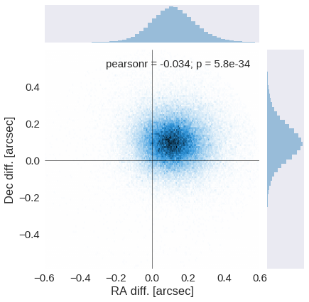

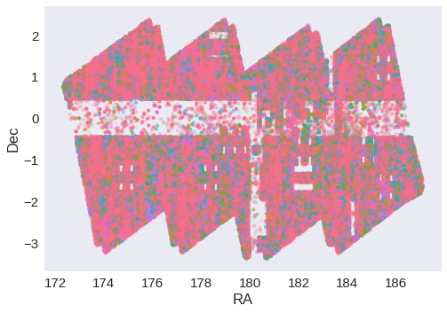

```python
nb_astcor_diag_plot(catalogue[RA_COL], catalogue[DEC_COL],
                    gaia_coords.ra, gaia_coords.dec)
```

```python
delta_ra, delta_dec =  astrometric_correction(
    SkyCoord(catalogue[RA_COL], catalogue[DEC_COL]),
    gaia_coords, near_ra0=True
)

print("RA correction: {}".format(delta_ra))
print("Dec correction: {}".format(delta_dec))
```

```
RA correction: -0.11539355086824798 arcsec
Dec correction: -0.09543808613279303 arcsec
```

```python
catalogue[RA_COL] +=  delta_ra.to(u.deg)
catalogue[DEC_COL] += delta_dec.to(u.deg)
```

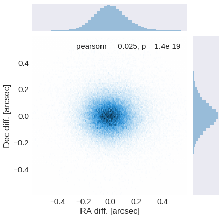

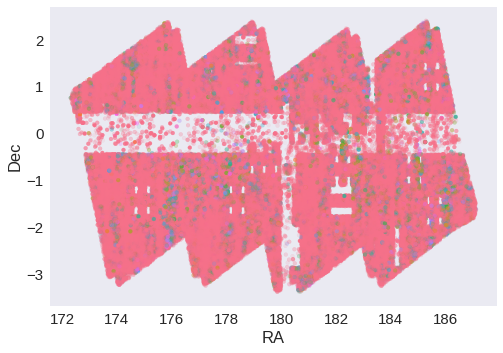

```python
nb_astcor_diag_plot(catalogue[RA_COL], catalogue[DEC_COL],
                    gaia_coords.ra, gaia_coords.dec)
```

## IV - Flagging Gaia objects

```python
catalogue.add_column(
    gaia_flag_column(SkyCoord(catalogue[RA_COL], catalogue[DEC_COL]), epoch, gaia)
)
```

```python
GAIA_FLAG_NAME = "las_flag_gaia"

catalogue['flag_gaia'].name = GAIA_FLAG_NAME
print("{} sources flagged.".format(np.sum(catalogue[GAIA_FLAG_NAME] > 0)))
```

```
135410 sources flagged.
```

## V - Flagging objects near bright stars

# VI - Saving to disk

```python
catalogue.write("{}/UKIDSS-LAS.fits".format(OUT_DIR), overwrite=True)
```